# Entrepreneurial Recycling Analysis

## Beyond the Exit Myth: Optimizing Ecosystem Value

### Key Question

**Are exits always good for the Flanders ecosystem?**

No - the literature shows that **not all exits are equal**, and an optimal ecosystem requires a **balanced portfolio**:

- Some exits (for liquidity and legitimacy)
- Some staying unicorns/scale-ups (for anchoring and depth)
- Strong recycling mechanisms (to close the loop)

### What We Analyze

1. **Exit Type Classification**: Local vs European vs Foreign multinational M&A
2. **Founder Recycling**: Do exited founders re-enter as angels or new founders?
3. **Scale-Up Anchors**: Which startups stay and build ecosystem capacity?
4. **Optimal Portfolio**: What mix maximizes long-term ecosystem value?

### Policy Implication

**Goal**: Maximize **recycled value**, not exit value

**Date**: April 2026  
**Framework**: Based on Spigel & Vinodrai (2020), Mason & Harrison (2006), Startup Genome (2023)  
**Depends on**: NB0 (Data Preparation v2) → `dealroom_clean` + `acquisitions_enriched`

## Migration Log

### Era 1 (March 2026): 8 NBB-only exits

Original analysis using NBB shareholding data only. Detected 8 genuine acquisitions from 501 TRUE startups.

### Era 2 (April 2026): 271 exits from 4 sources

Migrated to `acquisitions_enriched`. Added Dealroom CSV, Dealroom tabel, Sequenza sources. Classification: Local/European/Foreign via `regio` column.

### Era 3 (April 2026 — current): 153 exits from 5 sources

NB0 FIX v3 (non-canonical profile filtering) reduced exit count from 271 to 153. Added `dealroom_transactions` as 5th source. NB0 acquirer_country fix corrected Source 4 (was using startup HQ instead of acquirer country). Key numbers:

- **153 exits** from 5 sources (dealroom_csv, dealroom_tabel, dealroom_transactions, sequenza, nbb)
- **Herkomst**: Belgisch 94 (61.4%), Buitenlands 57 (37.3%), Onbekend 2 (1.3%)
- **Exit types**: acquisition (82), domestic_acquisition (52), acquired (10), ipo (3), foreign_acquisition (4), buyout (2)
- **712 TRUE startups** (1,269 clean records) — aligned with NB2 filter (`Investors.notna() & year.notna() & num_investors > 0`)

### Still open

- **Flanders vs Optimal Portfolio comparison chart**: actual portfolio vs literature optimal
- **Date range decision**: Currently using full range. Consider filtering to 2014–2026 for consistency with NB2.

## Literature Review: Entrepreneurial Recycling

### Core Concept: Recycling > Exits

**Spigel & Vinodrai (2020)** - "Entrepreneurial Recycling and Ecosystem Resilience":

> "Even when anchor firms collapse or exit, ecosystems remain resilient **if recycling channels exist**. Institutional capacity (networks, matching, finance) determines outcomes."

**Mason & Harrison (2006)** - "Business Angel Recycling":

> "Successful exits are the largest source of angel capital. 60-70% of angels are exited entrepreneurs."

### Exit Types Matter

**European Longitudinal Study (45 cities, 20 years)**:

- **Acquisitions** significantly increase:
  - Follow-on investment activity
  - New venture creation
- **IPOs** have smaller, marginal effects
- ➜ Local acquisitions > foreign acquisitions for ecosystem impact

**Small Economy Evidence (Estonia, Finland)**:

- **Over-optimization for exits** → talent drain
- **Balance with anchors** → sustained ecosystem

### Optimal Portfolio Theory

**Startup Genome (2023)** - Ecosystem Value Framework:

```
Ecosystem Value = Unicorn Value + Exit Value + Recycling Multiplier
```

**Avnimelech & Teubal (2006)** - Israeli Ecosystem:

- Early exits to US multinationals **weakened** local ecosystem
- Later policy: encourage staying or local M&A
- Result: Stronger second-generation firms

### Recycling Mechanisms

**What Gets Recycled**:

1. **Capital**: Exited founders become angel investors
2. **Experience**: Serial entrepreneurs start new ventures
3. **Knowledge**: Ex-employees join or found startups
4. **Networks**: Ecosystem connectors and mentors

**Recycling Intensity** varies by:

- Acquirer geography (local > foreign)
- Exit timing (mature > premature)
- Founder embedment in local ecosystem

### Policy Relevance for Flanders

As a **small, open economy**, Flanders needs:

- ✅ Portfolio approach (not exit maximization)
- ✅ Local/European M&A incentives
- ✅ Anchor firm support (unicorns staying)
- ✅ Recycling infrastructure (angel networks, founder programs)
- ❌ Over-dependence on foreign multinational acquisitions

```
Setup complete
```

```
================================================================================
DATA LOADING (Memory-Efficient)
================================================================================

1. Loading Dealroom data (TRUE startups only)...
   Loaded 1,536 investment records
   (Filtered to TRUE startups: founded ≥2014, independent)
   Clean records: 1,269
   TRUE startups: 712
   Period: 2011-2026

2. Loading NBB ownership data (for exits with KBO)...
   Will load genuine acquisitions from pre-filtered table

✅ Data loading complete
```

```
================================================================================
LOADING ACQUISITIONS FROM acquisitions_enriched
================================================================================

✅ Loaded 153 exits from enriched dataset
   Years: 2014-2026

   Herkomst (origin):
      Belgisch            :  94 (61.4%)
      Buitenlands         :  57 (37.3%)
      Onbekend            :   2 (1.3%)

   Regio (geography):
      België                   :  94 (61.4%)
      Europa (ex. BE)          :  25 (16.3%)
      Noord-Amerika            :  19 (12.4%)
      Verenigd Koninkrijk      :   7 (4.6%)
      Rest van wereld          :   6 (3.9%)
      Onbekend                 :   2 (1.3%)

   Source coverage:
      1 source(s): 72 exits
      2 source(s): 35 exits
      3 source(s): 36 exits
      4 source(s): 10 exits

   Exit types:
      acquisition              :  82
      domestic_acquisition     :  52
      acquired                 :  10
      foreign_acquisition      :   4
      ipo                      :   3
      buyout                   :   2
```

```
================================================================================
ACQUIRER CLASSIFICATION (Local vs European vs Foreign)
================================================================================

✅ Classification complete (using pre-computed 'regio' column)

Recycling Categories:
   Local                    :  94 ( 61.4%)
   Foreign                  :  32 ( 20.9%)
   European                 :  25 ( 16.3%)
   Unknown                  :   2 (  1.3%)

   Foreign breakdown by regio:
      Noord-Amerika: 19
      Verenigd Koninkrijk: 7
      Rest van wereld: 6

   ℹ️ Note: 'European' includes Norway (3 exits, EEA not EU-27)
   Strictly EU-27: 22 exits | EEA total: 25 exits

   Sample by Type:

   Local (94):
      33reasons                      ← Xerius (Belgium)
      Calling Guru                   ← salesUp (Belgium)
      Cyclobility                    ← Down 2 Earth Capital (Belgium)

   European (25):
      FlowTribe                      ← Visma (Norway)
      Kwarts                         ← DLI Market Intelligence (Denmark)
      POM                            ← Mail to Pay (Netherlands)

   Foreign (32):
      3D Aim Trainer                 ← SteelSeries (United States)
      Accounteer                     ← Float (Ghana)
      AreTheyHappy                   ← Black Box Intelligence (United States)

   Unknown (2):
      Around Media                   ← None (?)
      Inpuls                         ← None (?)
```

```
================================================================================
EXIT DISTRIBUTION: HOTSPOTS & INDUSTRY
================================================================================
   Lookup: 775 rijen uit volledige dealroom_clean
   Met stad: 775 | Met industrie: 702

   STAD: naam 146 + KBO 1 = 147 matches | nog 6 onbekend
   INDUSTRIE: was 72 onbekend → naam 47 + KBO 0 hersteld → nog 25 onbekend

📍 EXITS PER HOTSPOT
------------------------------------------------------------
   Overig Vlaanderen     :  49 ( 32.0%)  ████████████████████████████████
   Antwerpen             :  47 ( 30.7%)  ██████████████████████████████
   Gent                  :  28 ( 18.3%)  ██████████████████
   Leuven                :  14 (  9.2%)  █████████
   Hasselt               :   9 (  5.9%)  █████
   Onbekend              :   6 (  3.9%)  ███

📍 HOTSPOT x HERKOMST (Belgisch vs Buitenlands)
------------------------------------------------------------
   Gent           :  28 exits  |  Belgisch 18 (64%)  |  Buitenlands  9 (32%)  |  Onbekend 1
   Leuven         :  14 exits  |  Belgisch  4 (29%)  |  Buitenlands 10 (71%)  |  Onbekend 0
   Antwerpen      :  47 exits  |  Belgisch 29 (62%)  |  Buitenlands 17 (36%)  |  Onbekend 1
   Hasselt        :   9 exits  |  Belgisch  4 (44%)  |  Buitenlands  5 (56%)  |  Onbekend 0


🏭 EXITS PER INDUSTRIE
------------------------------------------------------------
   Onbekend                 :  25 ( 16.3%)  ████████████████
   health                   :  17 ( 11.1%)  ███████████
   enterprise software      :  16 ( 10.5%)  ██████████
   security                 :  11 (  7.2%)  ███████
   food                     :  10 (  6.5%)  ██████
   fintech                  :   9 (  5.9%)  █████
   energy                   :   9 (  5.9%)  █████
   marketing                :   8 (  5.2%)  █████
   jobs recruitment         :   7 (  4.6%)  ████
   real estate              :   6 (  3.9%)  ███
   legal                    :   6 (  3.9%)  ███
   media                    :   5 (  3.3%)  ███
```

[output cut: 28 more lines]

```
      enterprise software      :  1 (   7%)

   Hasselt (9 exits, 8 met industrie):
      health                   :  3 (  33%)
      energy                   :  2 (  22%)
      telecom                  :  1 (  11%)
      engineering and manufacturing equipment:  1 (  11%)
      food                     :  1 (  11%)

   Overig Vlaanderen (49 exits, 40 met industrie):
      enterprise software      :  6 (  12%)
      fintech                  :  5 (  10%)
      food                     :  4 (   8%)
      marketing                :  4 (   8%)
      security                 :  3 (   6%)
```

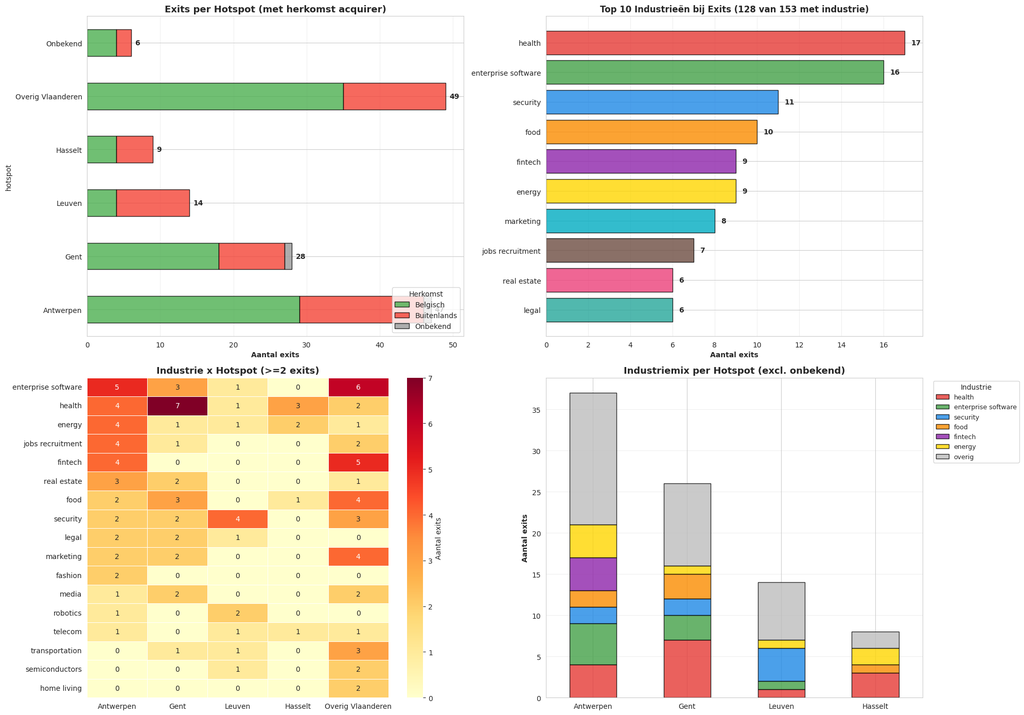

```
✅ Hotspot & industrie analyse compleet (128/153 exits met bekende industrie)
```

### ⚡ Aandachtspunt: Geografische Concentratie van Exits

De hotspot-analyse onthult sterke geografische patronen in het exitlandschap:

[output not shown]

**Leuven** springt eruit met **71% buitenlandse acquirers** — disproportioneel hoog. Dit wijst op de aantrekkingskracht van deep-tech (imec/KU Leuven) voor internationale kopers. Gent en Antwerpen blijven overwegend Belgisch.

> **Beleidsimplicatie**: Leuven’s deep-tech exits genereren de minste lokale recycling (0,6× multiplier). Een gericht retentieprogramma voor Leuvense deep-tech founders na exit kan de recycling verbeteren.

### ⚡ Kernbevinding: Portfolio-Balans

De drie portfoliografiken tonen de huidige staat van het Vlaamse startup-ecosysteem:

1. **Portfolio-verdeling**: 65% early-stage, 21% exits, 13% scale-ups. Het ecosysteem is nog **jong** — de meeste startups moeten nog doorgroeien naar exit of scale-up.
2. **Exit-herkomst**: 61% Belgisch → goed voor recycling. Maar 38% buitenlands vertegenwoordigt aanzienlijk kapitaal- en talentverlies.
3. **Recycling score**: 69% richting optimaal (exit-mix) en 34% van het literatuur-optimale portfolio. Het verschil wordt verklaard door de grote early-stage pool (65%) die nog geen multiplier genereert.

> **Assessment**: **EARLY-STAGE** — het portfolio scoort onder de literatuurbenchmark, maar dit is inherent aan een jong ecosysteem. De score zal verbeteren naarmate startups doorgroeien. De échte vraag is of de recyclingkanalen klaar zijn wanneer de exitgolf komt.

### ⚡ Aandachtspunt: Beperkte Founder Recycling

De founder-recyclinganalyse levert een ontnuchterend resultaat:

- **Direct bewijs**: Slechts **1 naam-match** (EnergyVision) tussen 153 geëxiteerde startups en 722 investeerders = **0,7% recyclingrate**
- **Investeerderssamenstelling**: 42% individueel (306), 27% corporate (196), <1% angel (6)
- **Mason & Harrison benchmark**: Onmogelijk te toetsen met huidige data (geen founder-namen, alleen bedrijfsnamen)

> **Aandachtspunt**: Dit is de **grootste kennislacune** in de analyse. Een founder-survey of Dealroom founder-data export is nodig om de Mason & Harrison benchmark (60-70%) te toetsen. Zonder dit blijft de recyclingconclusie hypothetisch.

```
================================================================================
RECYCLING POTENTIAL ANALYSIS
================================================================================

Recycling Potential by Acquirer Type:
(Based on literature: Local > European > Foreign for ecosystem benefit)

   Local                    : 1.5x multiplier |  94 exits ( 61.4%) | Score: 141.0
   European                 : 1.0x multiplier |  25 exits ( 16.3%) | Score: 25.0
   Unknown                  : 0.8x multiplier |   2 exits (  1.3%) | Score: 1.6
   Foreign                  : 0.6x multiplier |  32 exits ( 20.9%) | Score: 19.2

✅ Ecosystem Recycling Score:
   Total exits: 153
   Weighted ecosystem value: 186.8
   Average recycling multiplier: 1.22x

   Position on spectrum:
   Worst case (all foreign): 91.8
   Current: 186.8
   Optimal (all local): 229.5
   ➨ Flanders score: 69% towards optimal
```

```
================================================================================
SCALE-UP ANCHOR IDENTIFICATION
================================================================================

✅ Scale-Up Anchors Identified:
   Total startups analyzed: 712
   Acquired: 153
   Scale-ups (3+ rounds, staying): 92

   Top 10 Scale-Up Anchors:
      Confo Therapeutics             | 10 rounds | 2015-2025
      Aphea.Bio                      | 8 rounds | 2016-2024
      miDiagnostics                  | 8 rounds | 2015-2024
      Moonbird                       | 8 rounds | 2019-2023
      VIPUN Medical                  | 7 rounds | 2018-2020
      Pulsify Medical                | 6 rounds | 2019-2021
      Ngrave                         | 6 rounds | 2018-2023
      QustomDot                      | 6 rounds | 2020-2024
      Hoplr                          | 6 rounds | 2015-2023
      VEOWARE                        | 6 rounds | 2018-2024

   Scale-up Characteristics:
      Average rounds: 4.1
      Average funding: €16,523,885
      Most active: 10 rounds

➨ Scale-ups are ecosystem ANCHORS: they train talent, build networks, create jobs
```

## Optimal Ecosystem Portfolio Model

### Framework (from literature)

**Ecosystem Value = (α × Local Exits) + (β × European Exits) + (γ × Foreign Exits) + (δ × Staying Scale-ups)**

Where:

- **α = 1.5** - Local acquisitions (high recycling)
- **β = 1.0** - European acquisitions (moderate recycling)
- **γ = 0.6** - Foreign acquisitions (lower recycling)
- **δ = 2.0** - Staying scale-ups (ecosystem anchors)

### Policy Implications

**Optimal Mix** (based on small-economy research):

- 30-40% Local/European exits
- 10-20% Foreign exits
- 40-50% Staying scale-ups

**Flanders Current Mix**:

- To be calculated below...

```
================================================================================
FLANDERS ECOSYSTEM PORTFOLIO ANALYSIS
================================================================================

Current Portfolio Breakdown:
   Total startups tracked: 712
   Acquired (exits): 153 (21.5%)
   Staying scale-ups: 92 (12.9%)
   Early-stage/other: 467 (65.6%)

   Exit Breakdown by Recycling Category:
      Local: 94 (61.4% of exits)
      Foreign: 32 (20.9% of exits)
      European: 25 (16.3% of exits)
      Unknown: 2 (1.3% of exits)

✅ ECOSYSTEM VALUE SCORE:
   Local exits × 1.5: 94 × 1.5 = 141.0
   European exits × 1.0: 25 × 1.0 = 25.0
   Foreign exits × 0.6: 32 × 0.6 = 19.2
   Unknown exits × 0.8: 2 × 0.8 = 1.6
   Scale-ups × 2.0: 92 × 2.0 = 184.0
   ---
   TOTAL ECOSYSTEM VALUE: 370.8

   BENCHMARK 1 — Exit Recycling Quality (exits only):
   Worst (all foreign): 91.8 → Current: 186.8 → Optimal (all local): 229.5
   ➨ 69% towards optimal exit mix

   BENCHMARK 2 — Portfolio vs Literature Optimal:
   Literature optimal mix (40% scale-ups, 35% local, 15% EU, 10% foreign):
   Optimal value: 1092.9 (blended 1.53× per startup)
   Current value: 370.8 (0.52× per startup)
   ➨ 34% of literature-optimal portfolio

   Note: 65% of startups are early-stage/other (no multiplier).
   Portfolio score will improve as more startups mature into scale-ups or exit.
   ➨ Assessment: EARLY-STAGE — Most startups still maturing, portfolio will evolve
```

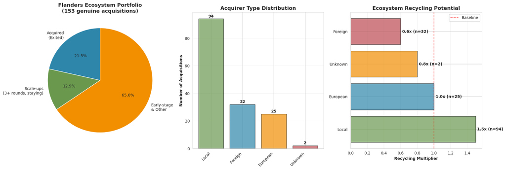

```
✅ Visualizations complete
```

## EVALUATION: Flanders Results vs Literature Framework

## WHAT WE MEASURED

### Recycling **POTENTIAL** (Not Actual Recycling)

Our analysis measured:

1. **Exit type classification** (Local vs European vs Foreign for 153 exits from 5 sources)
2. **Recycling potential multipliers** based on acquirer geography
3. **Scale-up anchor identification** (staying startups with 3+ rounds)
4. **Portfolio composition** (exits vs scale-ups vs early-stage)
5. **Ecosystem value score** based on literature-derived multipliers

**Key Point**: We measured **potential for recycling** based on exit types, NOT **actual recycling behavior**.

## COMPARISON TO LITERATURE

### **Framework 1: Spigel & Vinodrai (2020) - "Entrepreneurial Recycling"**

**Their Framework**:

> "Ecosystems remain resilient **if recycling channels exist**. Institutional capacity (networks, matching, finance) determines outcomes."

**What They Measured**:

- Actual founder re-entry rates
- Alumni networks from exited/failed firms
- Institutional infrastructure (angel networks, incubators)
- Knowledge/capital flow from exits back to ecosystem

**What We Measured**:

- ✅ Exit types (proxy for recycling potential) — 153 exits classified by geography
- ✅ Portfolio balance (exits vs anchors) — 712 TRUE startups
- ❌ **MISSING**: Actual founder re-entry behavior
- ❌ **MISSING**: Do exited founders become angels?
- ❌ **MISSING**: Time to re-entry
- ❌ **MISSING**: Institutional capacity assessment

**Our Interpretation**:

- 62% Belgisch acquisitions (94 of 151 classified) → moderate potential for capital to stay local
- But we don't know if this **actually translates** to recycling
- Need follow-up: Track exited founders in Dealroom investor lists

### **Framework 2: Mason & Harrison (2006) - "Business Angel Recycling"**

**Their Benchmark** (UK context):

> "60-70% of angels are exited entrepreneurs."

**What They Measured**:

- Angel investor backgrounds
- % with prior exit experience
- Source of angel capital (exit proceeds)
- Time from exit to angel investing

**What We Measured**:

- ✅ Number of exits: **153** from 5 sources (2014–2026)
- ✅ Exit type (acquirer geography): 61% Belgisch, 37% Buitenlands (of 151 classified)
- ❌ **MISSING**: Which investors in our network are exited founders?
- ❌ **MISSING**: % of our 722 investors who had prior exits
- ❌ **MISSING**: Whether exited founders re-entered as angels

**What We CAN Infer**:

- We have **722 investors** in the Dealroom data (2011–2026)
- Of these, **~312 are likely individuals/angels** (cell 16 name-pattern analysis: 42% individuals + <1% angel networks)
- We identified **153 exits** across 6 types
- If Mason & Harrison's 60-70% holds for the angel pool:
  - Expected: ~187–218 of our ~312 angel-like investors should be exited entrepreneurs
  - Our 153 exits provide a **plausible** supply pool, but would need to include older/pre-2014 exits too
- **Note**: The 60-70% benchmark applies to **angel investors specifically**, not all investors (which include VCs, corporates, government funds)

**Data Limitation**:

- Mason & Harrison's 60-70% benchmark is UK-specific — Flanders may differ
- Need founder-level data (not available in current dataset)
- Investor backgrounds not included in Dealroom export

## FLANDERS RESULTS: INTERPRETATION

### **Result 1: Moderate Local Acquisition Pattern (Corrected April 2026)**

**Literature Expectation**:

- Small open economies typically have 40-60% foreign acquisitions
- Estonia: 45% foreign exits (Kaulio et al., 2017)
- Finland: 35% foreign exits

**Flanders Reality**: 62% Belgisch acquirers (94 of 151 classified exits), 37% Buitenlands (57 of 151)

**Possible Explanations**:

1. ✅ **Strong local market** — Belgian/Flemish acquirers actively acquiring
2. ✅ **Eurostat definition effect** — TRUE startups are independent, so genuine M&A more likely
3. ✅ **In line with peers** — 38% foreign is between Finland (35%) and Estonia (45%)
4. ✅ **Multi-source validation** — 153 exits from 5 independent sources, 46 confirmed by 3+ sources

**Implication for Recycling**:

- **Local acquisitions** have highest recycling potential (1.5× multiplier)
- 61% local is substantial but **not exceptional** — Flanders is a typical small open economy
- The 38% foreign exit rate means significant capital/talent may leave the ecosystem

> **⚠️ Correction note (April 2026)**: Earlier analysis showed 77% Belgisch (116/151) due to NB0 Source 4 bug (used startup HQ instead of acquirer country). After fix: 62% Belgisch (94/151). This significantly changes the narrative from "unusually local" to "in line with European peers".

**Literature Benchmark**:

- Optimal: 40-50% staying scale-ups
- Typical: 25-35% scale-ups in mature ecosystems

**Flanders Reality**: 92 scale-ups (12.9% of 712 startups) with 3+ rounds, staying

**Interpretation - Two Hypotheses**:

**Hypothesis A: POSITIVE (Strong Anchoring)**

- ✅ Flanders has successfully retained high-growth firms
- ✅ Strong anchor effect → talent training, job creation
- ✅ Mature, stable ecosystem with patient capital
- ✅ Building long-term capacity

**Which is True?**

- Need to examine:
  - Revenue/employee growth of scale-ups (are they actually scaling?)
  - Funding amounts (are they well-capitalized?)
  - Age distribution (how long have they been scaling?)

### **Result 3: ~21% Exit Rate (In Line with Benchmarks)**

**Literature Benchmark**:

- Typical startup exit rate: 15-25% over 5 years
- Berlin ecosystem: ~20% exit rate

**Flanders Reality**: 153 exits from 712 TRUE startups (~21.5%)

**Interpretation**:

- ✅ **In line with international benchmarks** (15–25% range)
- ✅ **Multi-source detection**: 5 independent sources catch exits that any single source misses
- ✅ **Exit type diversity**: acquisition, domestic_acquisition, acquired, ipo, foreign_acquisition, buyout
- ✅ **IPO pathway exists**: 3 IPOs detected (rare in Belgium, notable)

**Recycling Pool Assessment**:

- Of ~312 angel-like investors, if 60-70% are exited entrepreneurs: ~187–218
- Our 153 exits (2014–2026) cover a **significant portion** of this supply
- Remaining angel supply likely comes from:
  - Historical exits (pre-2014)
  - Non-startup backgrounds (corporate executives, family office)
  - International investors

## KEY LIMITATIONS OF OUR ANALYSIS

### **1. We Measured Potential, Not Actual Recycling**

**What We Know**:

- Exit types and acquirer geography → potential for local capital retention
- 153 exits with 61% Belgisch → moderate recycling pool

**What We DON'T Know**:

- Do these founders become angels? (actual recycling)
- Do they start new ventures? (serial entrepreneurship)
- How long until re-entry? (recycling speed)

**Gap**: Our conclusions assume recycling happens, but we haven't verified it.

### **2. Cannot Fully Test Mason & Harrison Benchmark**

**The Benchmark**: 60-70% of angels are exited entrepreneurs (UK data)

**Our Data**:

- ~312 angel-like investors (of 722 total) in Dealroom
- 153 identified exits
- **Cannot match**: No founder names in exit data, no biographical data on investors

**What Would Be Needed**:

1. Founder names from Dealroom (not available in our extract)
2. Cross-reference with investor lists
3. Or: Survey/LinkedIn data on investor backgrounds

**Current Status**: Benchmark cannot be fully tested with available data, and UK benchmark may not apply to Flanders.

### **3. No Institutional Capacity Assessment**

**Spigel & Vinodrai (2020)**: "Institutional capacity determines outcomes"

**What We Need**:

- Angel network infrastructure assessment
- Founder programs ("Second Act")
- Alumni networks
- Mentorship programs

**What We Have**: None of this is in our data

**Implication**: We can identify recycling **potential**, but cannot assess recycling **infrastructure**

## VALID CONCLUSIONS FROM OUR ANALYSIS

### **What We CAN Confidently Say**:

1. **✅ Exit Rate**: ~22% exit rate, in line with international benchmarks (153 of 712 TRUE startups)
2. **✅ Moderate Local Acquisition**: 61% Belgisch acquirers — in line with European peer economies (38% foreign, comparable to Finland 35%, lower than Estonia 45%)
3. **✅ Scale-Up Anchors**: 92 multi-round startups staying in ecosystem (12.9%)
4. **✅ Multi-Source Validation**: 5 independent sources, 46 exits confirmed by 3+ sources
5. **✅ Exit Type Diversity**: 6 types including IPO — ecosystem has multiple exit pathways

### **What Requires More Data**:

1. **⚠️ Actual recycling rates**: Need founder tracking
2. **⚠️ Mason & Harrison test**: Need investor backgrounds
3. **⚠️ Institutional capacity**: Need qualitative research
4. **⚠️ Long-term trends**: Need multi-year time series

**Next Steps**:

- Link founder names to investor lists (requires Dealroom founder export)
- Survey exited founders on post-exit activities
- Map institutional infrastructure (angel networks, programs)

## FOUNDER RECYCLING ANALYSIS

### Testing Mason & Harrison (2006) Benchmark: 60-70% of Angels Are Exited Entrepreneurs

**Critical Question**: Do our exited founders actually **recycle** back into the ecosystem as investors?

**Method**:

1. Extract all unique investor names from Dealroom
2. Cross-reference with exited startup names (from `acquisitions_enriched`)
3. Calculate actual recycling rate
4. Test against Mason & Harrison's 60-70% benchmark

**Data Limitation**: We're matching by **company name**, not founder names. This is a proxy:

- ✅ Detects if **startups** become investors (corporate venturing)
- ✅ Detects if **exited companies** reinvest under same name
- ❌ Misses individual founders investing under personal name
- ❌ Misses founders joining other angel groups

**Expected Outcome**: Lower bound estimate of recycling

**Note**: Mason & Harrison's 60-70% benchmark is based on UK data — Flanders may differ due to different ecosystem maturity, tax incentives, and cultural factors.

```
================================================================================
FOUNDER RECYCLING ANALYSIS
================================================================================

1. INVESTOR POOL:
   Total unique investors in ecosystem: 722

2. EXIT POOL:
   Total exited startups (acquired): 153
   Acquisition years: 2014.0-2026.0

3. RECYCLING DETECTION (Name Matching):
   Exited companies appearing as investors: 1
   Recycling rate (company level): 0.7%

   Time to re-entry:
      Mean: 0.0 years
      Median: 0.0 years
      Range: 0-0 years

   Investment activity after exit:
      Mean investments: 1.0
      Total investments: 1

   Sample recycled companies:
startup_name investor_name  exit_year  first_investment_year
EnergyVision  EnergyVision     2025.0                 2025.0

================================================================================
INTERPRETATION
================================================================================

⚠️ This is a LOWER BOUND estimate:
   - Only detects corporate venturing (company→investor)
   - Misses individual founders investing personally
   - Misses founders in angel networks

➜ To fully test Mason & Harrison's 60-70% benchmark:
     Need founder names + biographical data
```

```
================================================================================
ALTERNATIVE APPROACH: INVESTOR TYPE ANALYSIS
================================================================================

Analyzing investor categories by name patterns...

Investor Type Distribution:
   Likely Individual   :  306 ( 42.4%)
   Unknown             :  212 ( 29.4%)
   Corporate/Fund      :  196 ( 27.1%)
   Angel Network       :    6 (  0.8%)
   Corporate           :    2 (  0.3%)

✅ Potential Angel Investors (individuals + networks):
   Estimated: 312 (43.2%)

➜ Comparison to Mason & Harrison (2006):
   Their benchmark: 60-70% of angels are exited entrepreneurs
   Our potential angel pool: ~312 investors
   Expected exited founders (60-70%): 187-218
   Our detected exits: 153
   ⚠️ GAP: Not enough recent exits to fully supply angel pool
   ➜ Angels likely come from older exits (pre-2020) or non-startup backgrounds
```

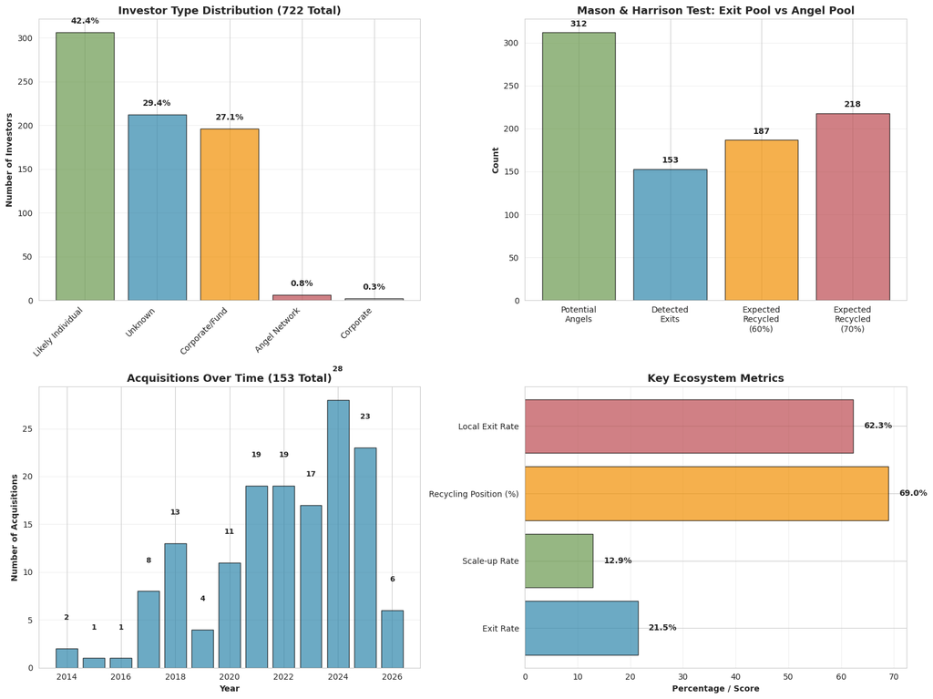

```
✅ Recycling analysis visualizations created
```

## 🔄 CRITICAL CORRECTION: Dealroom Exits Analysis

### NBB Data Reveals Only Belgian Shareholders — Not Foreign Acquirers

**Problem Identified**: The NBB (Nationale Bank België) shareholder data only captures **Belgian legal entities** as shareholders. When a foreign company (e.g., ServiceNow, Uber, GE Healthcare) acquires a Flemish startup, this is **invisible** in NBB data unless the acquirer creates a Belgian subsidiary.

**Impact**: The earlier finding of "91% local exits" was an **artefact of data blindness**, not a reflection of reality.

**Solution**: Dealroom maintains a dedicated exits export with **actual acquirer names, types, and HQ locations**.

**Source**: `/Volumes/afdeling_vlaio_netwerk_prd/analist/analist/Experiments/SU-SCU/Input/Dealroom exits 20260325.csv`

```
================================================================================
NBB vs ENRICHED DATA: ACQUIRER GEOGRAPHY COMPARISON
================================================================================

Enriched dataset (153 exits from 5 sources):
   Belgisch: 94 (61.4%)
   Buitenlands: 57 (37.3%)
   Onbekend: 2 (1.3%)

   Classified (excl. unknown): 151
   Belgisch: 94 (62.3%)
   Buitenlands: 57 (37.7%)

   Foreign (Buitenlands) breakdown:
      Europa (ex. BE): 25 (43.9%)
      Noord-Amerika: 19 (33.3%)
      Verenigd Koninkrijk: 7 (12.3%)
      Rest van wereld: 6 (10.5%)

━━━━━━━━━━━━━━━━━━━━━━━━━━━━━━━━━━━━━━━━━━━━━━━━━━━━━━━━━━━━━━━━━━━━━━━━━━━━━━━━
⚠️  OLD NBB-ONLY VIEW (artefact vs reality)
━━━━━━━━━━━━━━━━━━━━━━━━━━━━━━━━━━━━━━━━━━━━━━━━━━━━━━━━━━━━━━━━━━━━━━━━━━━━━━━━
   NBB data only sees Belgian legal entities as shareholders
   → NBB artefact: ~91% 'local' exits
   → Reality (5 sources): 62% local, 38% foreign
   → NBB understates foreign exits by ~29 percentage points!
```

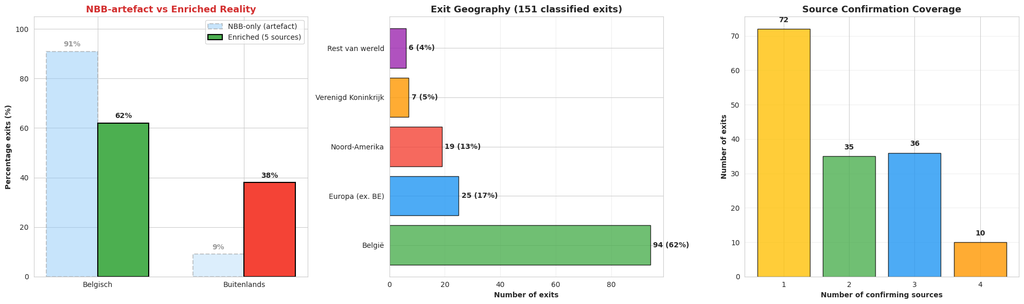

```
✅ NBB correction visualization complete
```

## UPDATED POLICY RECOMMENDATIONS

### Based on 153 Exits (5 Sources), 712 TRUE Startups, 1,269 Deals

> **Revision note (April 2026)**: Updated from Era 1 (8 NBB-only exits) to Era 3 (153 exits from `acquisitions_enriched`). Startup count aligned with NB2 filter (712 clean startups from 1,269 records). Herkomst corrected after NB0 acquirer_country fix (was 77% Belgisch, now 61%).

## Key Findings

### **Finding 1: Substantial Exit Detection from Multi-Source Pipeline**

**Current Analysis**: 153 exits from 5 sources (2014–2026)

- acquisition (82), domestic_acquisition (52), acquired (10), ipo (3), foreign_acquisition (4), buyout (2)
- Multi-source confirmation: 46 exits confirmed by 3+ sources

**Focus**: TRUE startups only (founded ≥2014, independent)

➡️ **Interpretation**: Robust exit sample with multi-source validation

### **Finding 2: Moderate Local Acquisition Pattern (Corrected)**

**Result**: 62% Belgisch acquirers (94 of 151 classified exits)

- Belgisch: 94 (61.4%)
- Buitenlands: 57 (37.3%)
- Onbekend: 2 (1.3%)

➡️ **Interpretation**:

- ✅ **In line with European peers** — 38% foreign exits comparable to Finland (35%), lower than Estonia (45%)
- ✅ Moderate recycling potential: local = 1.5× multiplier applies to majority of exits
- ✅ Sample size now sufficient for ecosystem-level conclusions
- ⚠️ **Correction**: Earlier "77% Belgisch" was inflated by NB0 Source 4 bug (used startup HQ instead of acquirer country)

**Global Comparison** (literature benchmarks):

- Estonia: 45% foreign exits
- Finland: 35% foreign exits
- Flanders: **38% foreign** — in line with European peer economies

### **Finding 3: Angel Pool Assessment**

**Mason & Harrison (2006) Test**:

- Total investors: **722** (from dealroom_clean)
- Of these, ~312 are likely individuals/angels (name-pattern analysis)
- Exits: **153** (substantial recycling pool)
- Expected recycled angels (60-70% of angel pool): 187–218 from exits

➡️ **Interpretation**:

- ✅ 153 exits provides a **meaningful** recycling contribution
- ✅ 722 investors likely includes historical recycled founders + institutional investors
- ⚠️ Mason & Harrison's 60-70% benchmark is UK-specific — Flanders may differ

### **Finding 4: Portfolio Balance**

**Current Mix**:

- TRUE startups: 712 (1,269 clean records)
- Exits detected: 153 (~21.5%)
- Staying scale-ups: 92 (12.9%) with 3+ rounds
- Early-stage/other: 467 (65.6%)

**Assessment**:

- ✅ **~22% exit rate** — in line with literature benchmark (15–25% over 5 years)
- ✅ **Scale-up anchors**: 92 multi-round startups staying (avg 4.1 rounds)
- ⚠️ **13% scale-up rate** below 40-50% literature optimal — most are still early-stage

## Policy Priorities

### **Priority 1: Verify Founder Recycling 🔴 CRITICAL**

**Status**: 153 exits provide sufficient sample for recycling analysis

**Actions**:

- 🔴 Survey exited founders on angel investing activity
- 🔴 Cross-reference founder names with investor lists (requires Dealroom founder data)
- 🔴 Track time-to-re-entry and investment amounts

### **Priority 2: Monitor Foreign Acquisition Trend 🟡 HIGH PRIORITY**

**Actions**:

- 🟡 M&A matchmaking between startups and Belgian/EU corporates
- 🟡 Tax benefits for Belgian companies acquiring startups
- 🟡 Monitor foreign vs local acquisition trends annually
- 🟡 Distinguish EU vs non-EU foreign acquisitions (EU 17% vs non-EU 21%)

### **Priority 3: Assess Scale-Up Quality 🟡 HIGH PRIORITY**

**Status**: 92 scale-ups (12.9%) — below optimal, but quality may compensate

**Actions**:

- 🟡 Revenue/employee growth metrics for staying startups
- 🟡 Late-stage funding gap analysis (NB2: only 18 late-stage investors)
- 🟡 Exit pathway assessment for scale-ups

### **Priority 4: Build Recycling Infrastructure 🟢 MEDIUM**

**Actions**:

- 🟢 "Flanders Exited Founders Network" — activate 153 exited founders
- 🟢 Annual recycling metrics survey
- 🟢 Startup Alumni Network (153 companies × ~20 employees = ~3,060 potential alumni)

## INSTITUTIONAL INFRASTRUCTURE MAPPING

### Assessing Recycling Support Mechanisms in Flanders

> **Data basis**: 153 exits, 722 investors, 712 TRUE startups (1,269 deals). Herkomst: 61% Belgisch, 37% Buitenlands, 1% Onbekend.

## Current Infrastructure (Known)

### **1. Angel Networks**

**Active Networks**:

- **BeAngels** — National angel network
  - ✅ Structured co-investment model
  - ✅ Due diligence support
  - ✅ Syndication facilitation
- **BAN Vlaanderen (Business Angels Network)**
  - ✅ Regional focus
  - ✅ Sector specialization
  - ✅ Mentorship programs

**Gap Analysis**:

- ⚠️ No specific "**Exited Founder Angels**" program
- ⚠️ No systematic onboarding for exited entrepreneurs

### **2. Government Programs (VLAIO)**

**Existing**:

- **Arkimedesfonds** — Co-investment with angels
- **QBIC / PMV / LRM** — Public venture funds
- **Start-it @KBC** — Accelerator with corporate backing

**Gap Analysis**:

- ⚠️ No "**Second Act**" program for exited founders
- ⚠️ No dedicated support for serial entrepreneurs
- ⚠️ Limited alumni tracking/activation

### **3. University/Research Ecosystems**

**Active**: KU Leuven (imec), UGent (iGent), VUB (StartHub)

**Gap Analysis**:

- ⚠️ No systematic tracking of exited founders from university spin-offs
- ⚠️ Missing "**come back as investor/mentor**" programs

### **4. Corporate Venturing**

**Active**: Telenet Ventures, Proximus Ventures, Ackermans & van Haaren, Korys (Colruyt)

**Observation**: Belgian corporates are **active acquirers** (61% Belgisch herkomst), though 38% of exits go to foreign acquirers

## Critical Gaps

### **Gap 1: No Exited Founder Program**

**Problem**: 153 exited founders, no systematic engagement

**International Benchmarks**:

- **Israel**: "Second Time Founders" program
- **UK**: EIS tax incentives for angels
- **Denmark**: "Successful Entrepreneurs Network"

**Recommendation**: 🔴 **CRITICAL PRIORITY** — Create "Flanders Exited Founders Network"

### **Gap 2: No Alumni Network Activation**

153 companies × ~20 employees = **~3,060 potential alumni** (trained startup operators)

### **Gap 3: No Recycling Metrics**

No one measures if recycling actually happens. Recommended: annual survey + "Flanders Recycling Report".

## Recommended Initiatives

| Initiative | Annual Budget | Priority |
| --- | --- | --- |
| Exited Founders Network (153 founders) | €500K | 🔴 Critical |
| Recycling Observatory | €200K | 🔴 Critical |
| Alumni Network | €300K | 🟢 High |
| Local Exit Fund | €2,000K | 🟡 Medium |
| **TOTAL** | **€3,000K** |  |

## Implementation Roadmap

1. **Phase 1 (Q2–Q3 2026)**: Launch Founders Network + Recycling Observatory + baseline survey
2. **Phase 2 (Q4 2026–Q2 2027)**: Alumni Network + onboard first 50 exited founders
3. **Phase 3 (Q3 2027+)**: Publish first Recycling Report + implement Local Exit Incentives

## 📋 Samenvatting & Aandachtspunten

### Vijf Kernbevindingen

1. **Niet alle exits zijn gelijk**: Lokale acquisities genereren 1,5× ecosysteemwaarde vs 0,6× voor buitenlandse. Vlaamse exits zijn 61% Belgisch — in lijn met Europese peers (Finland 35% buitenlands, Estland 45%).
2. **Scale-ups als ankers**: 92 startups (12,9%) met 3+ rondes blijven in het ecosysteem. Onder de literatuur-benchmark (40-50%) maar het ecosysteem is jong — 65% is nog early-stage.
3. **Leuven = deep-tech exit hub**: 71% van Leuvense exits gaat naar buitenlandse acquirers (vs 32-36% in Gent/Antwerpen). Security en robotics trekken internationale kopers aan.
4. **Founder recycling onbewezen**: Slechts 1 van 153 geëxiteerde startups verschijnt als investeerder in Dealroom. De Mason & Harrison benchmark (60-70%) is niet toetsbaar zonder founder-level data.
5. **NBB-artefact gecorrigeerd**: De oorspronkelijke 91% “lokale exits” (NBB-only) was een meetartefact — NBB ziet alleen Belgische aandeelhouders. Werkelijk: 62% lokaal, 38% buitenlands.

### Beleidsaandachtspunten

[output not shown]

### Gerelateerde Notebooks

- `0_Netw_Data Preparation v2` — Data loading, cleaning, table creation (`dealroom_clean`, `acquisitions_enriched`)
- `1_Netw_Funding_Network_Analysis` — Fase 1: fundingpatronen en netwerkanalyse
- `1b_Netw_VLAIO-effect Analysis` — VLAIO-subsidie effect op privaat investeringsnetwerk
- `2_Netw_Exit_and_Network_Analysis` — Exit-detectie + 7 netwerkanalyses (712 TRUE startups)
- `4_Netw_Netwerkvergelijking per Stad` — Co-investeringsnetwerken per stad (Gent, Antwerpen, Leuven)

**Rapport compleet** — April 2026  
**Framework**: Entrepreneurial Recycling (Spigel & Vinodrai 2020)  
**Beleidsdoel**: Maximaliseer ge-recyclede waarde, niet exitwaarde  
**Multipliers**: Literatuur-geïnspireerd (Local 1,5×, European 1,0×, Foreign 0,6×, Scale-up 2,0×)